# Dataset: ‘dataset_1-1stLine_bin’ summary

## ‘EMB’ Details

Significant SNPs over lambda

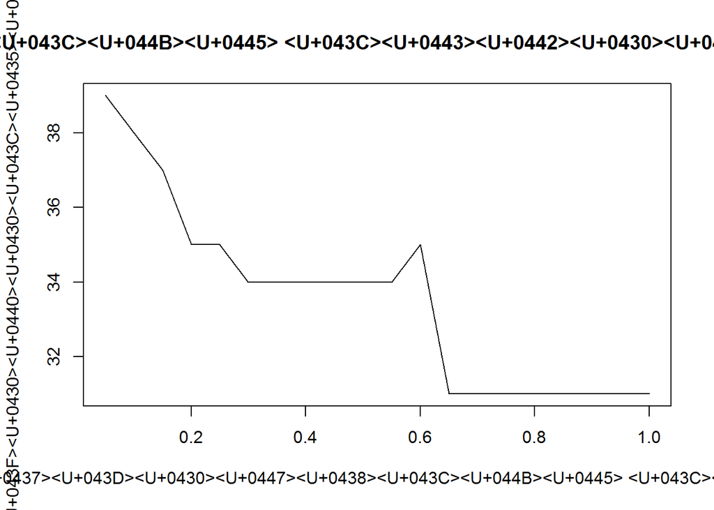

F1 score over lambda

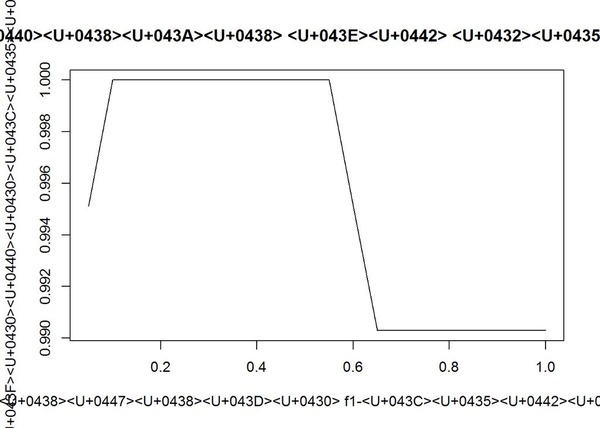

## ‘INH’ Details

Significant SNPs over lambda

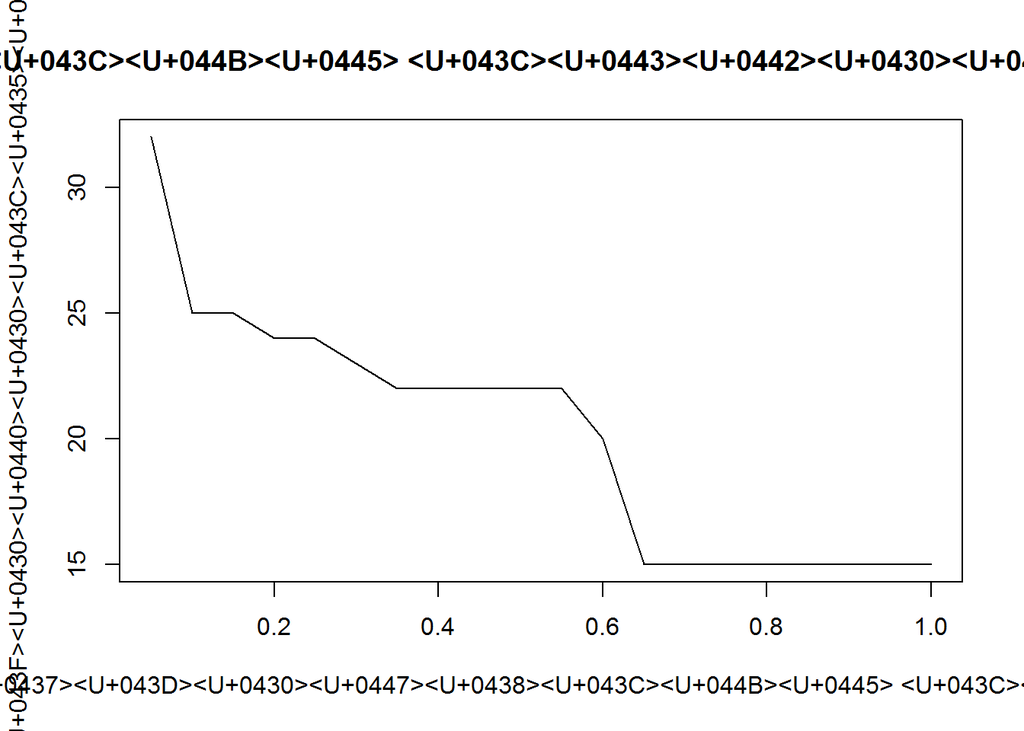

## ‘OFLO’ Details

Significant SNPs over lambda

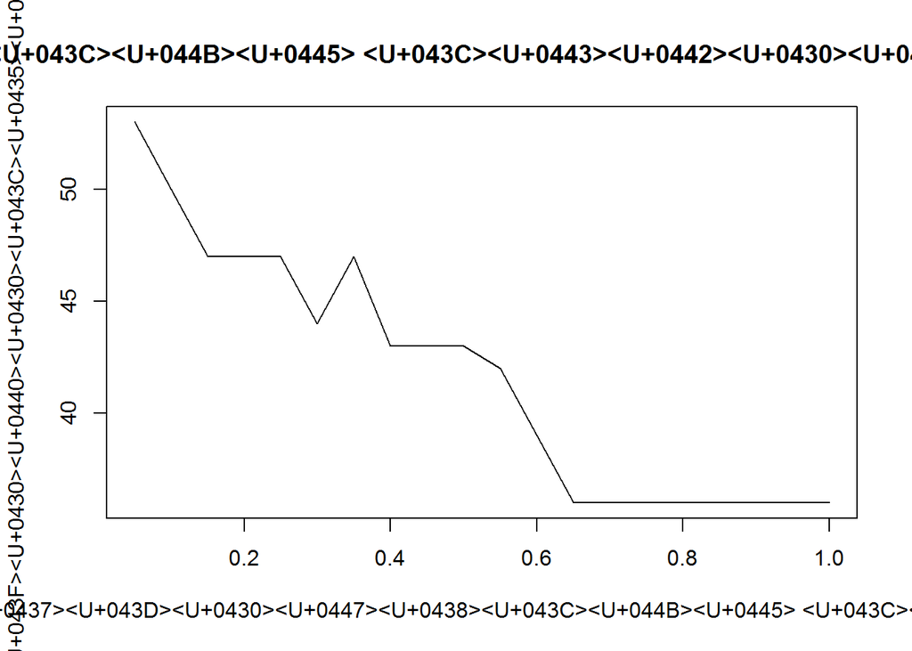

F1 score over lambda

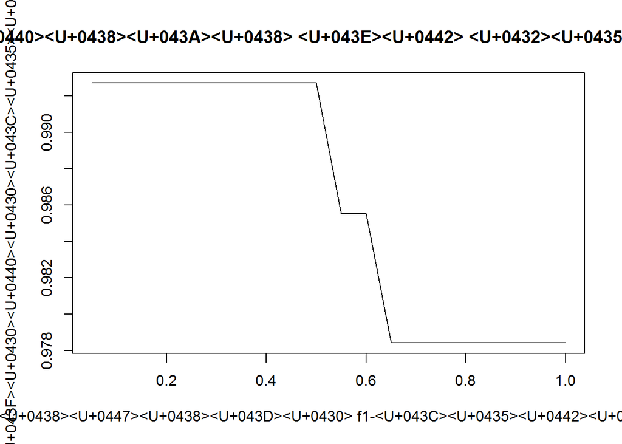

## ‘PZA’ Details

Significant SNPs over lambda

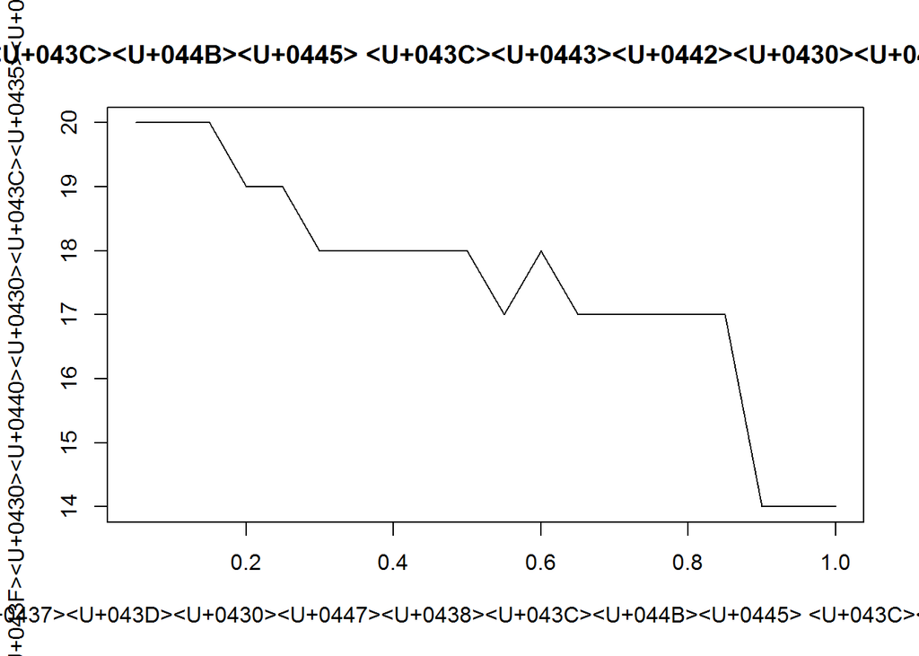

F1 score over lambda

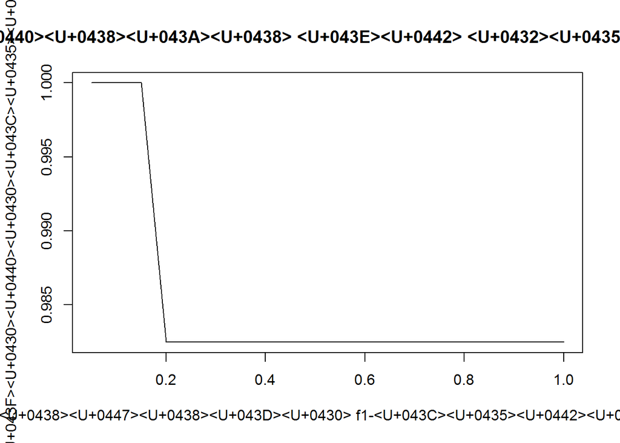

## ‘RIF’ Details

Significant SNPs over lambda

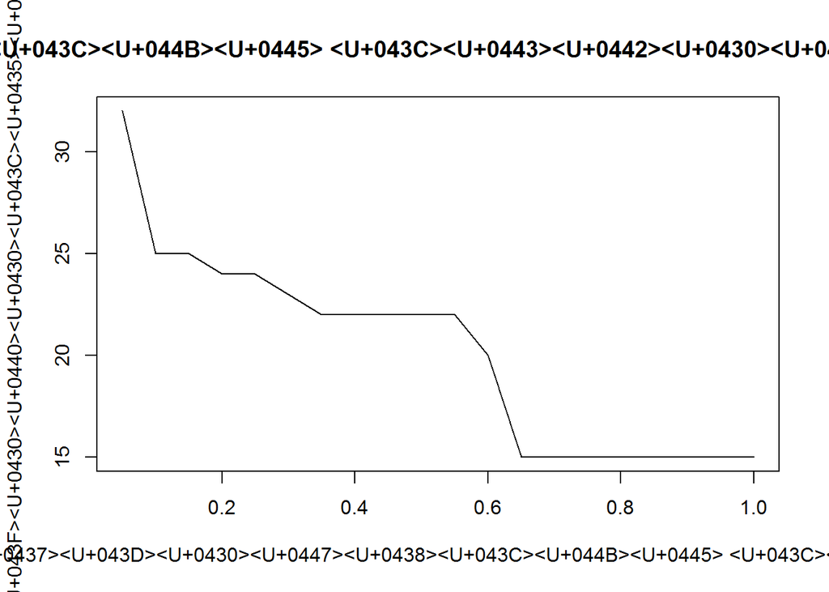

## ‘STM’ Details

Significant SNPs over lambda

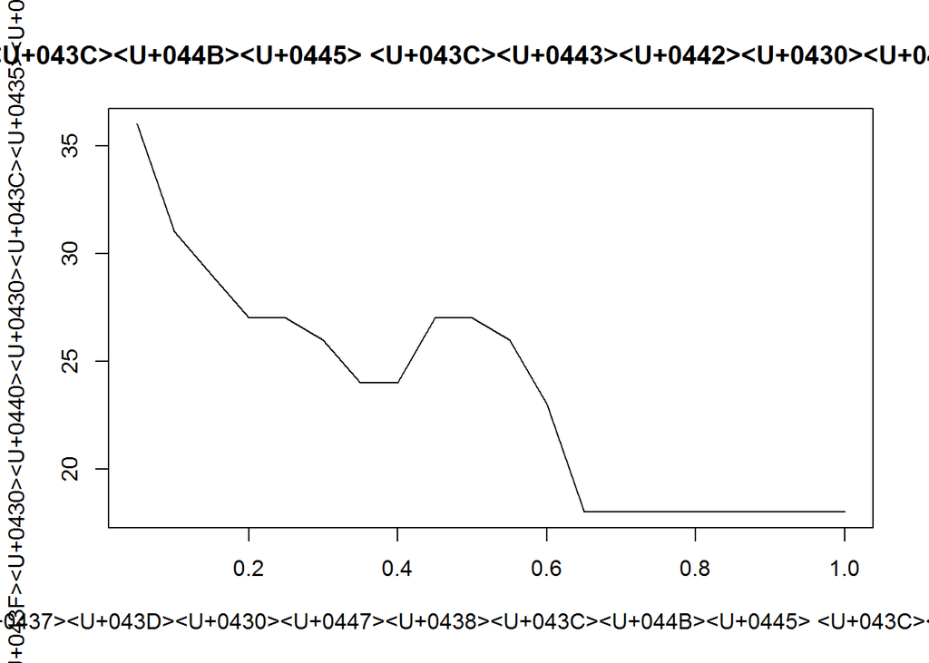

F1 score over lambda

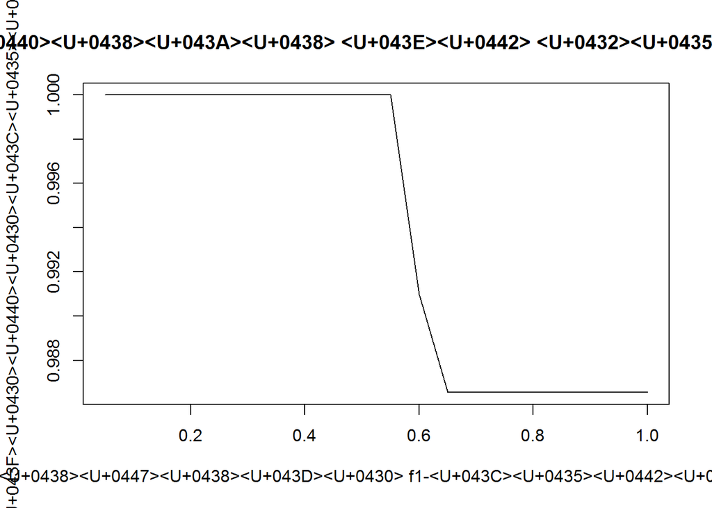

# Dataset: ‘dataset_2-S-2ndLine_bin’ summary

## ‘OFLO’ Details

Significant SNPs over lambda

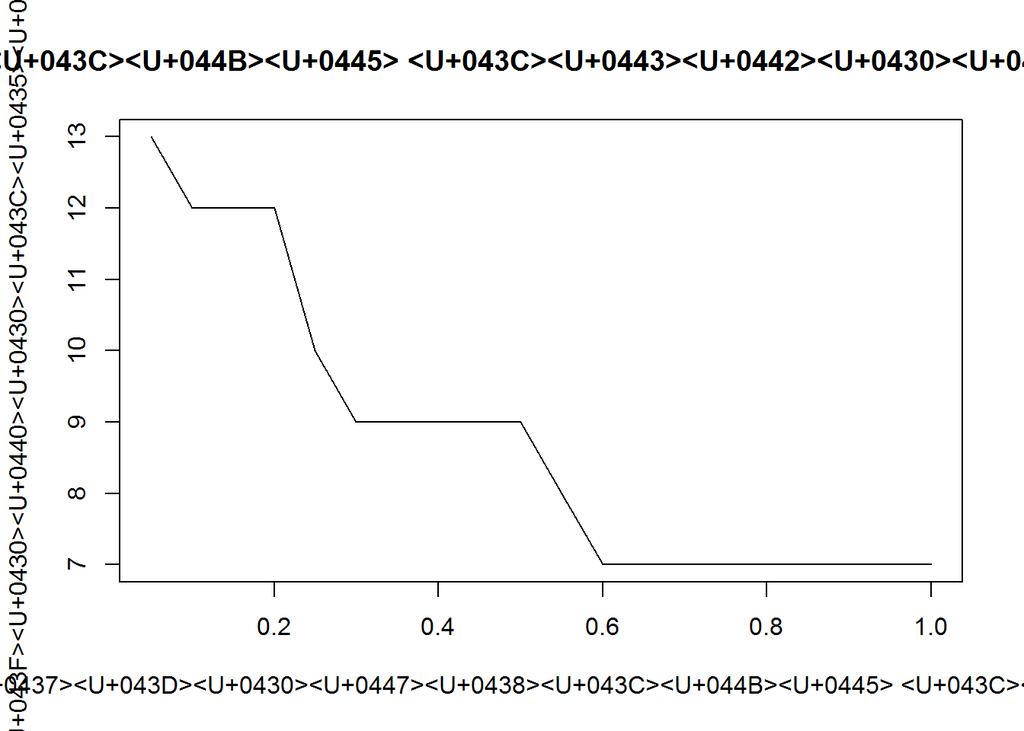

# Dataset: ‘dataset_3-S-oflo_bin’ summary

## ‘AMIK’ Details

Significant SNPs over lambda

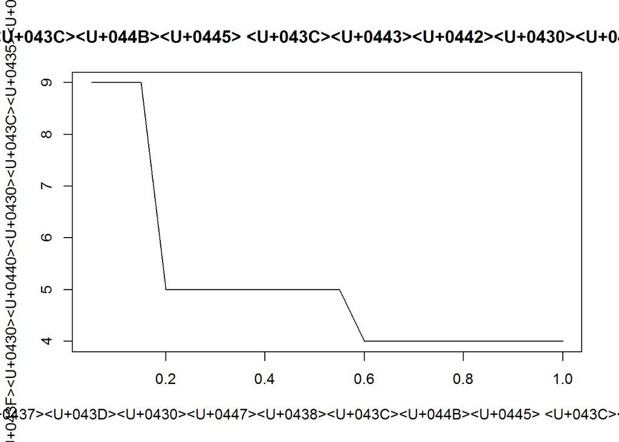

## ‘CAPR’ Details

Significant SNPs over lambda

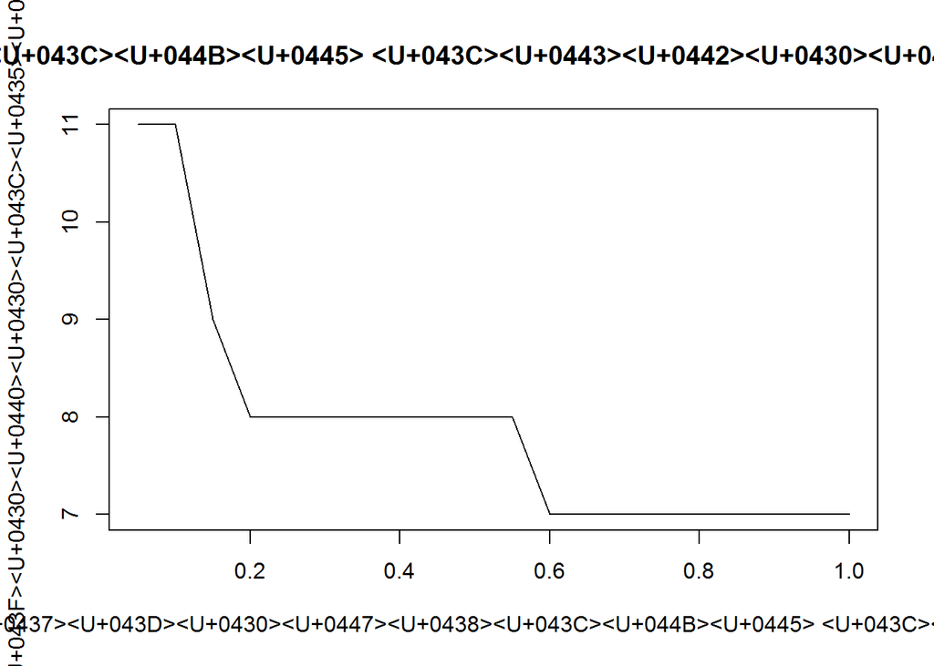

# Dataset: ‘dataset_4-S-II_oflo_bin’ summary

## ‘OFLO’ Details

Significant SNPs over lambda

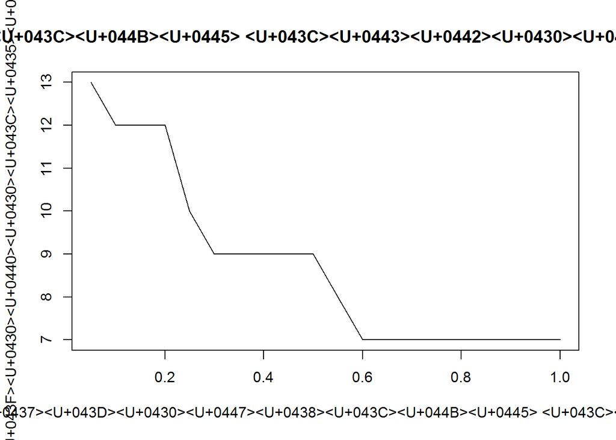

# Dataset: ‘dataset_4.1-S-2ndLine_R-rifm_OFLO_bin’ summary

## ‘OFLO’ Details

Significant SNPs over lambda

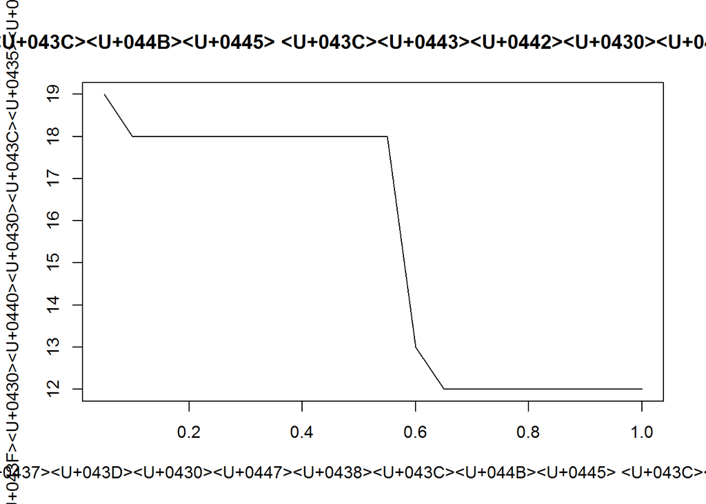

# Dataset: ‘dataset_5-S-ami_capr_bin’ summary

## ‘CAPR’ Details

Significant SNPs over lambda

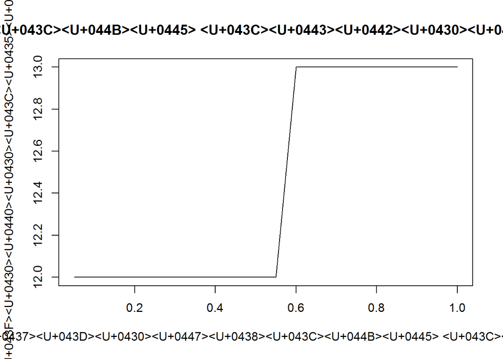

# Dataset: ‘dataset_6-2ndLine_Inj_bin’ summary

## ‘AMIK’ Details

Significant SNPs over lambda

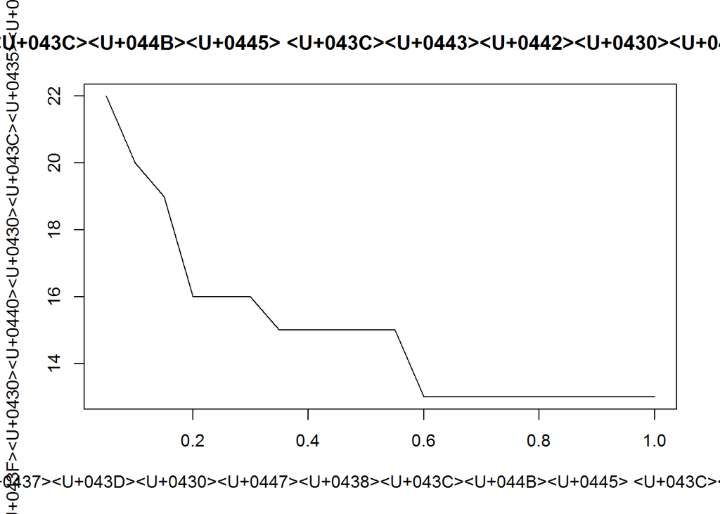

F1 score over lambda

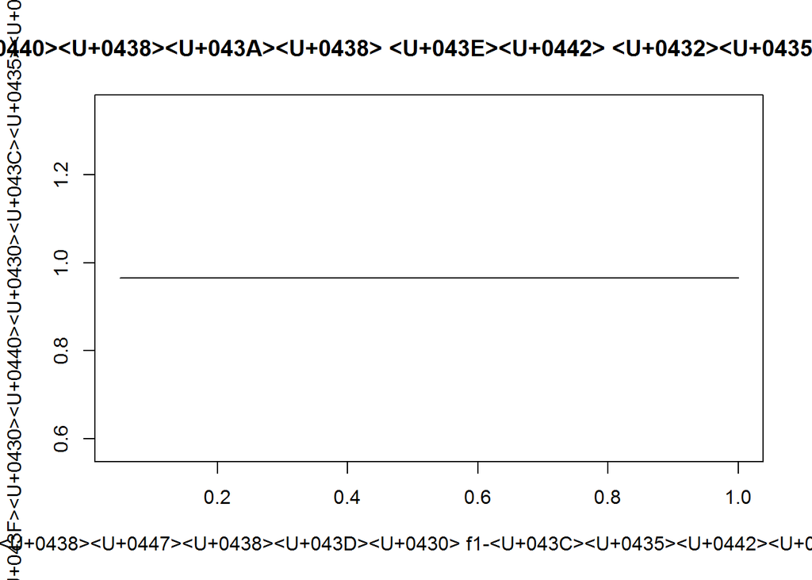

## ‘CAPR’ Details

Significant SNPs over lambda

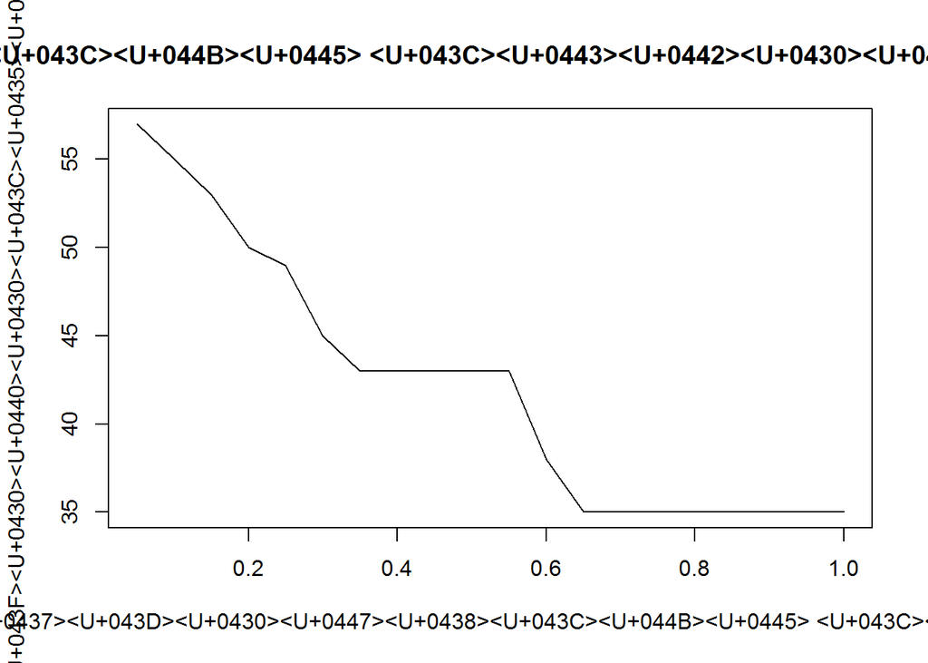

F1 score over lambda

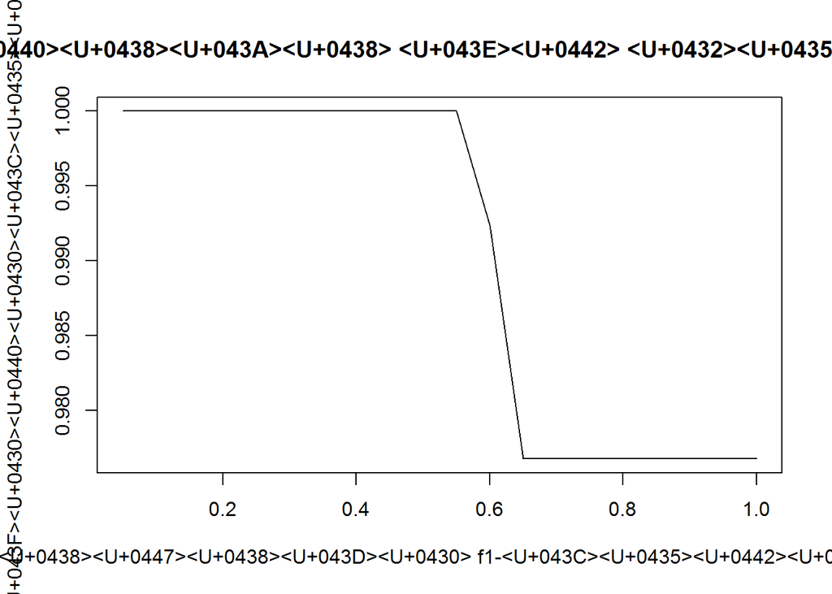

# Dataset: ‘dataset_7-S-oflo_R-rifm_bin’ summary

## ‘AMIK’ Details

Significant SNPs over lambda

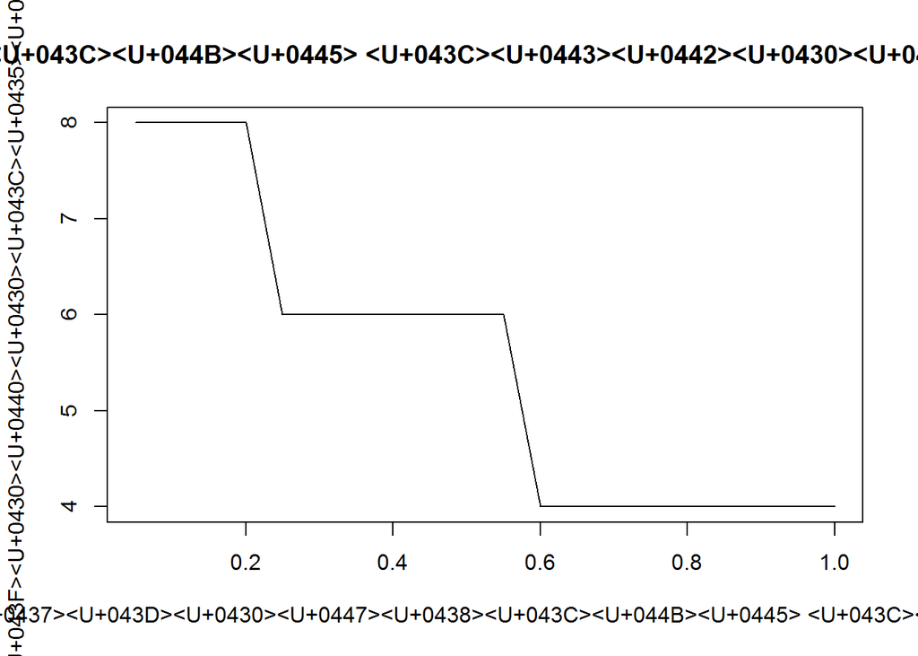

## ‘CAPR’ Details

Significant SNPs over lambda

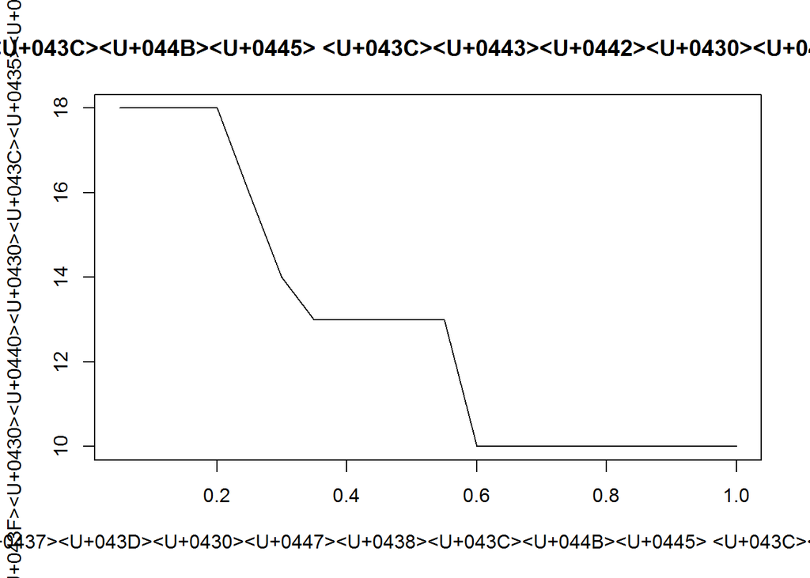

# Dataset: ‘dataset_8-S-II_2ndLineNonInj_bin’ summary

## ‘CYCL’ Details

Significant SNPs over lambda

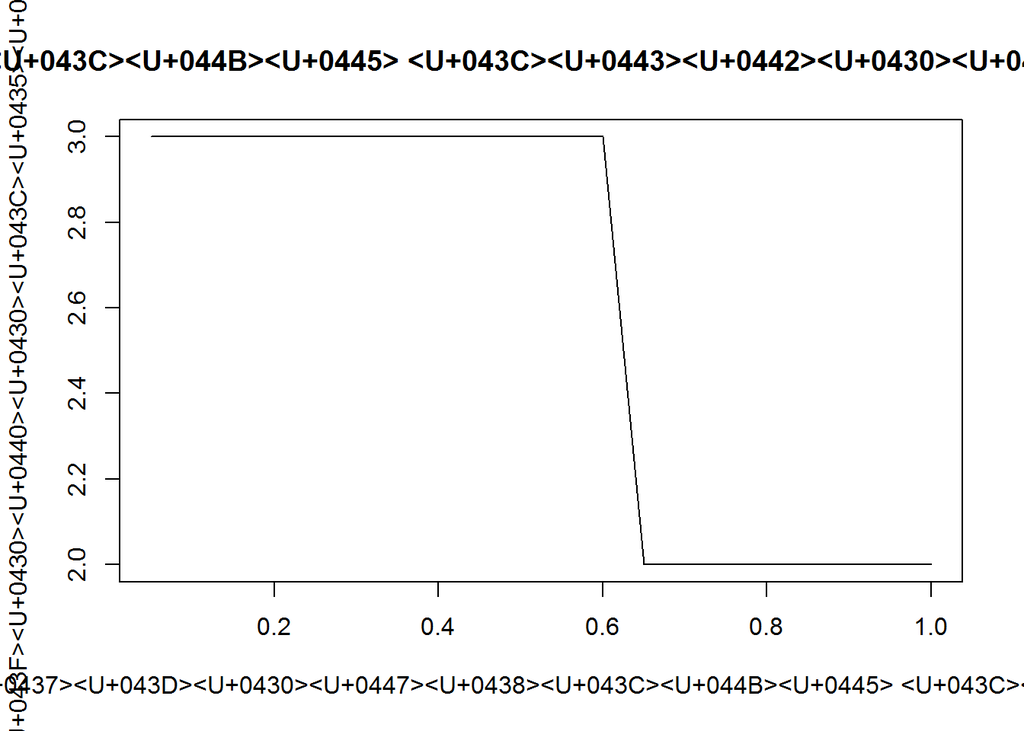

F1 score over lambda

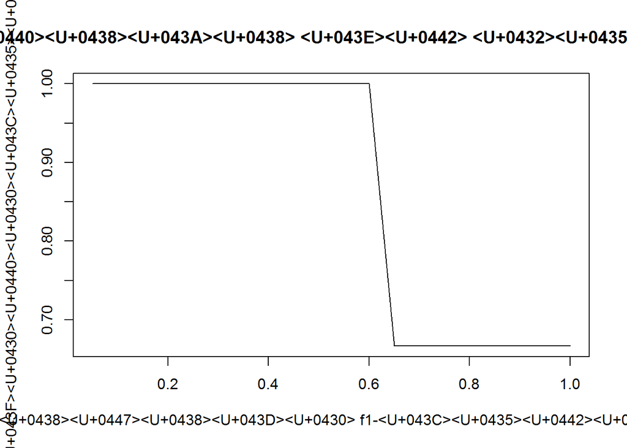

## ‘PARA’ Details

Significant SNPs over lambda

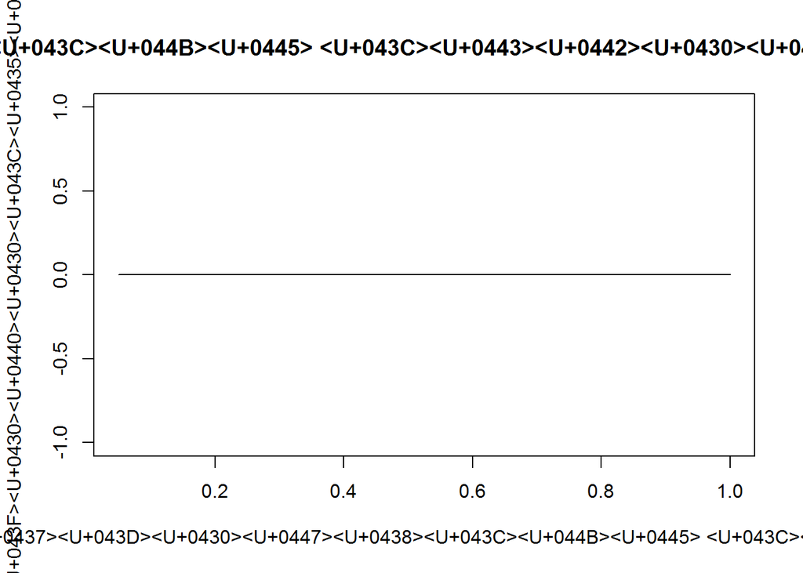

F1 score over lambda

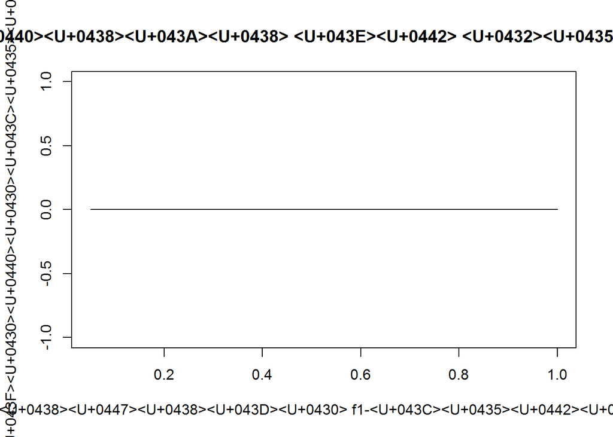

# Dataset: ‘dataset_9-2ndLineNonInj_bin’ summary

## ‘CYCL’ Details

Significant SNPs over lambda

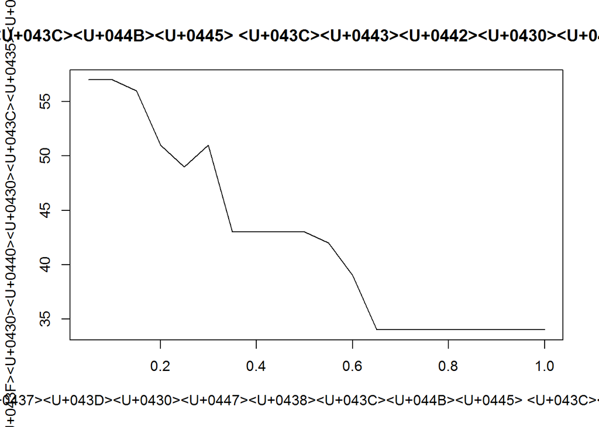

F1 score over lambda

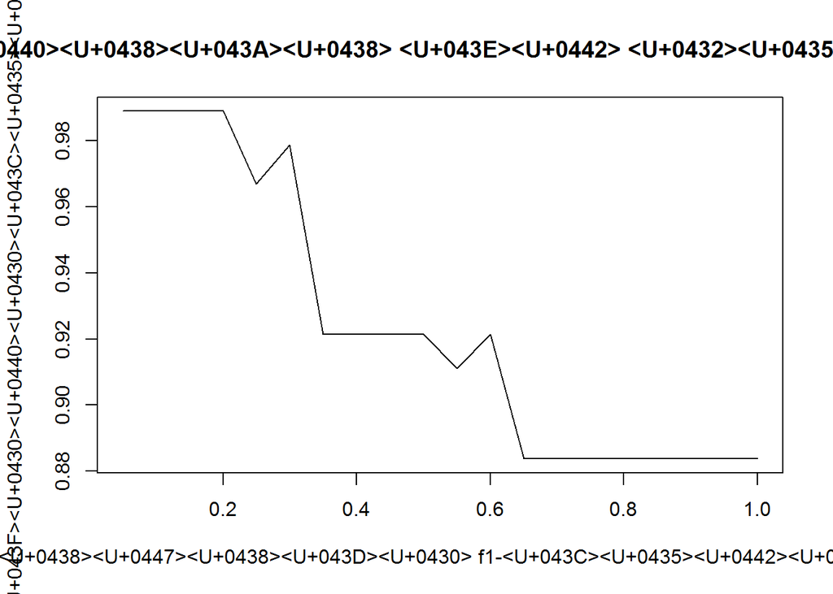

## ‘ETH’ Details

Significant SNPs over lambda

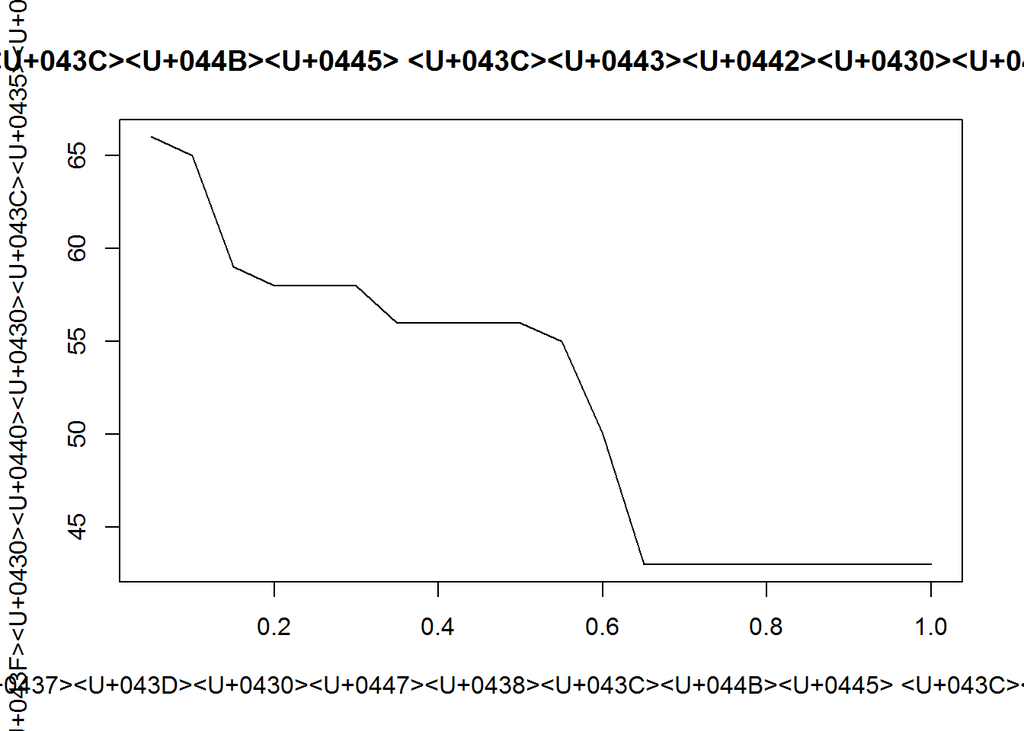

F1 score over lambda

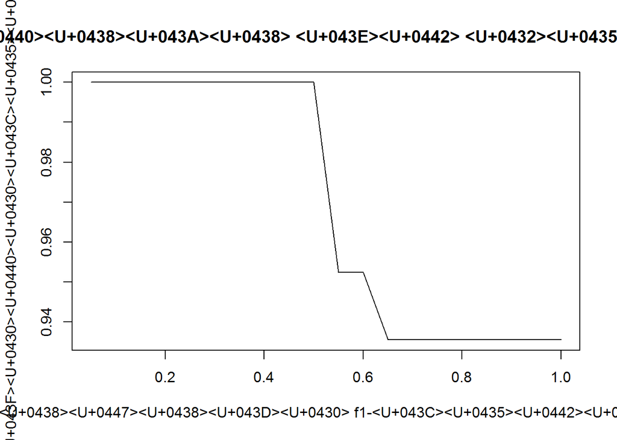

## ‘PARA’ Details

Significant SNPs over lambda

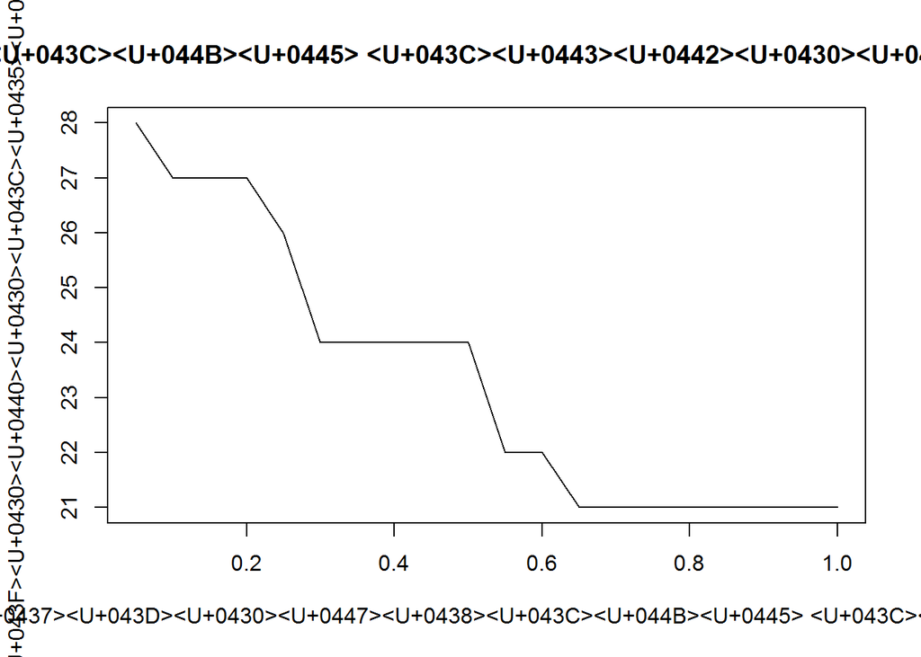

F1 score over lambda

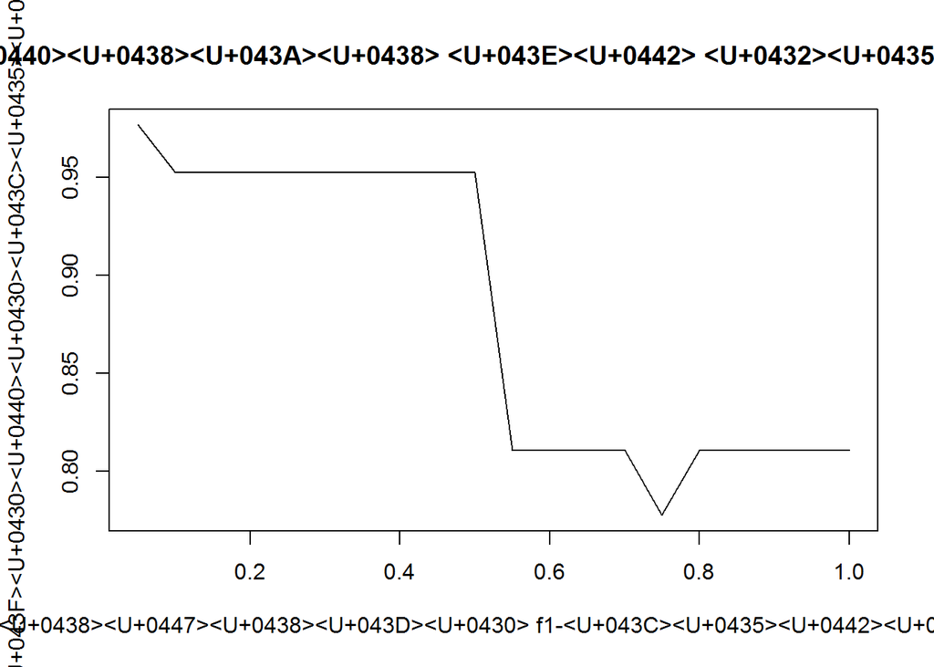